# SSL Future Proof Project Update - August 1 2022

### Demographic and detection rate estimates

Survival rates were estimated for ages P, 1:9, and age 10+, with fixed effects estimating the effect of pup mass and the differences between sex and natal region on survival over 19 years of data. The sample sizes for natal region were imbalanced, with more samples from Pyramid Rock (*n* = 1395) than South Seal Rock (*n* = 290). Fixed effects of sex were estimated for each age group while those of natal region were estimated for pups, yearlings, shared for juveniles (ages 3-6) and adults (ages 7-10+). Temporal variance was estimated using a random effect of year with a penalized complexity prior, with the random effect estimated for pups, yearlings, and pooled for juveniles (ages 3-6) and adults (ages 7-10+) jointly for both sex and natal region (i.e., trends were not estimated for each sex nor region but for age groups in the eDPS as a whole).

Detection rates were estimated for each age as above with temporal variance constructed in the same fashion, but detection was assumed to be constant across sexes, natal regions, and resight location.

#### Survival rates

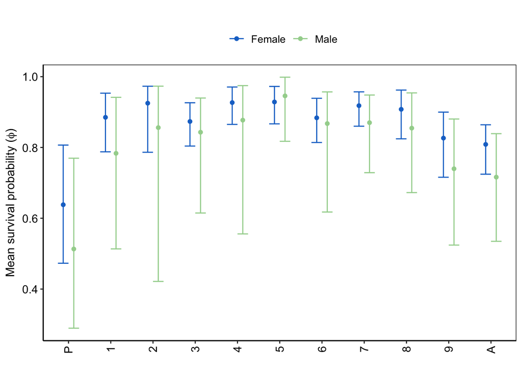

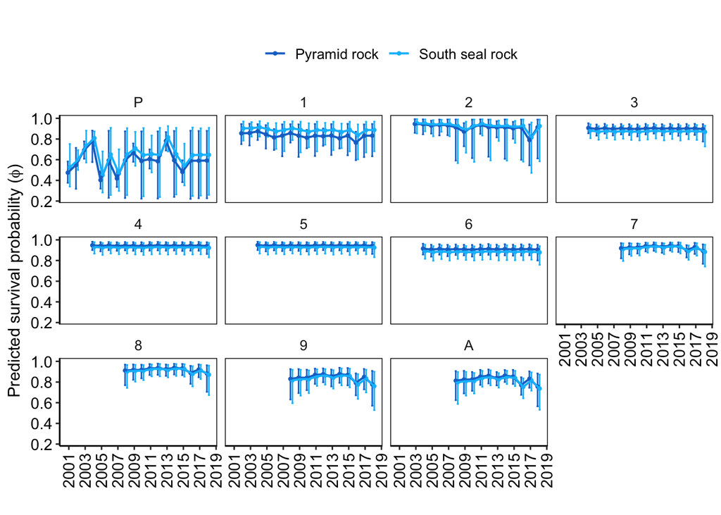

#### Detection rates

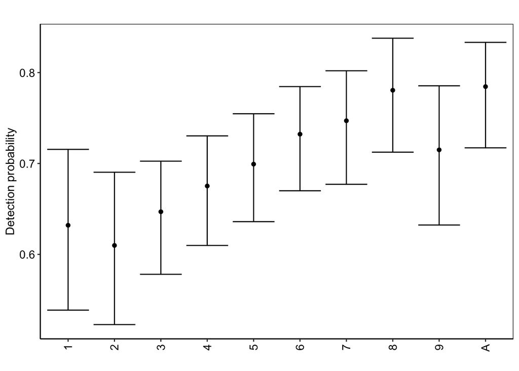

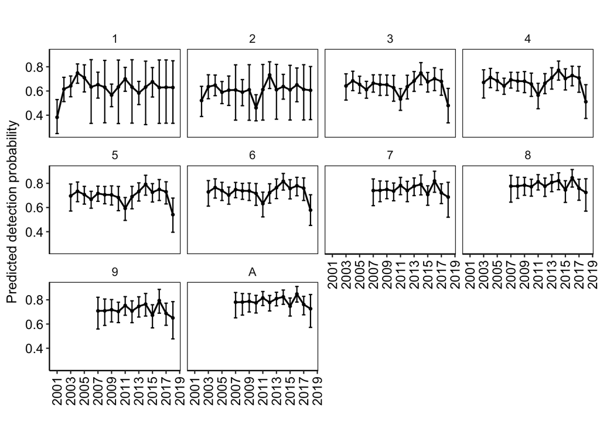

### Simulation analysis

| scenario | survey_freq | detection | N | tot | prop_conv |
| --- | --- | --- | --- | --- | --- |
| 1 | Annual | Low | 50 | 50 | 1 |
| 2 | Annual | Low | 200 | 50 | 1 |
| 3 | Annual | Med | 50 | 50 | 1 |
| 4 | Annual | Med | 200 | 50 | 1 |
| 5 | Annual | High | 50 | 50 | 1 |
| 6 | Annual | High | 200 | 50 | 1 |
| 7 | Biennial | Low | 50 | 50 | 1 |
| 8 | Biennial | Low | 200 | 50 | 1 |
| 9 | Biennial | Med | 50 | 50 | 1 |
| 10 | Biennial | Med | 200 | 50 | 1 |
| 11 | Biennial | High | 50 | 50 | 1 |
| 12 | Biennial | High | 200 | 50 | 1 |

#### Relative bias

Plots showing relative bias for survival and detection across 12 simulation scenarios.

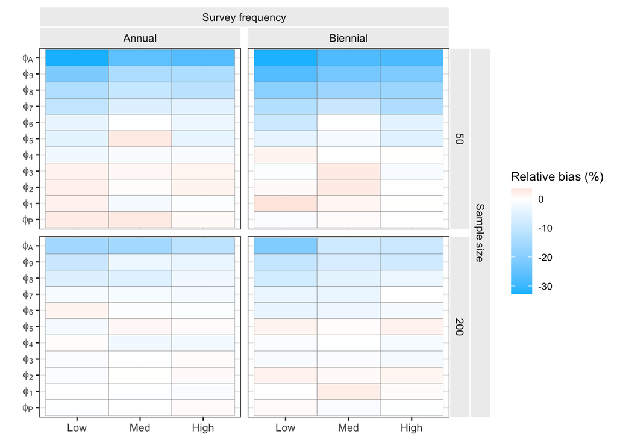

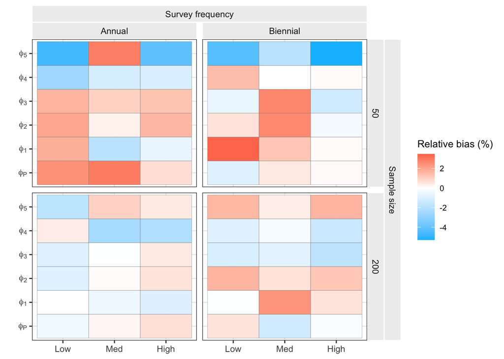

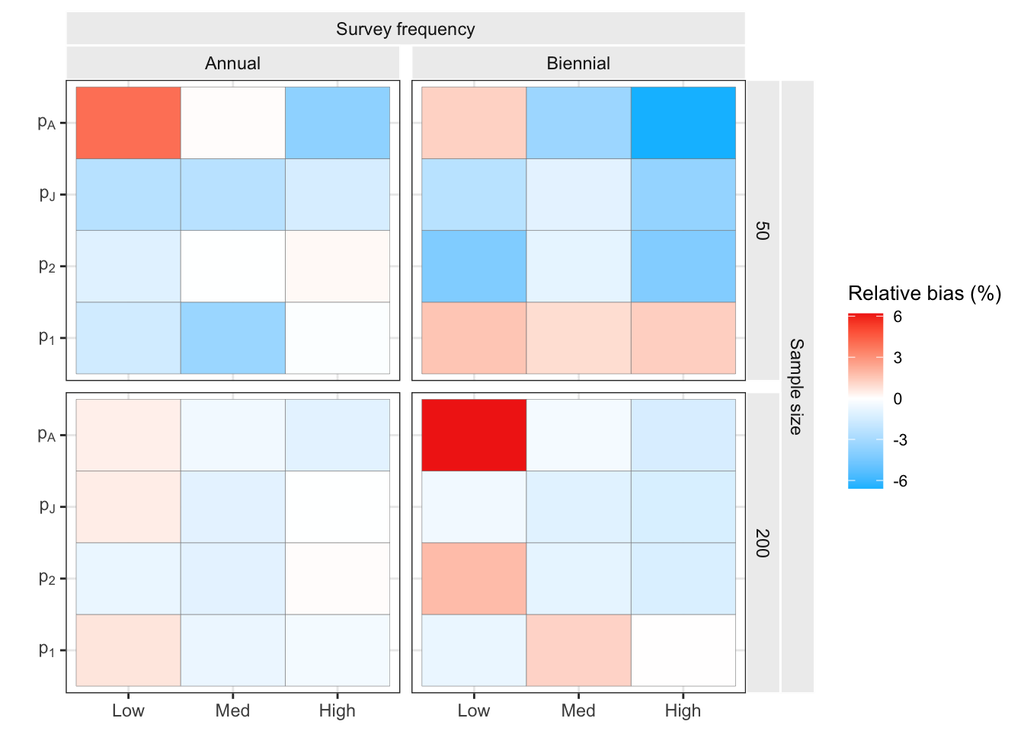

#### Root mean square error (RMSE)

Plots showing RMSE for survival and detection across 12 simulation scenarios.

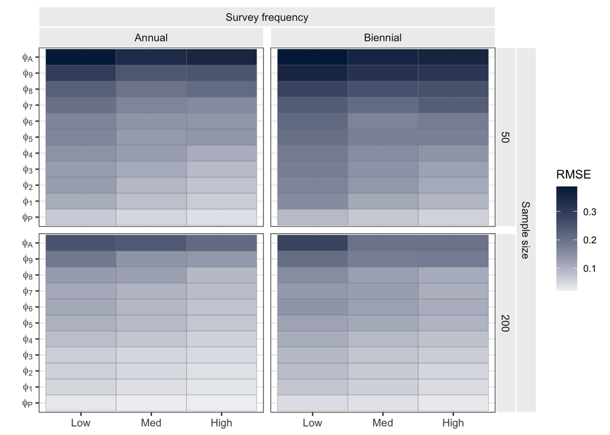

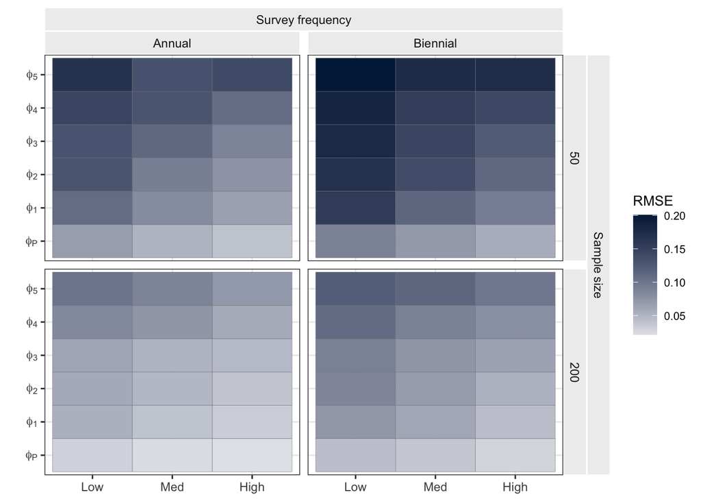

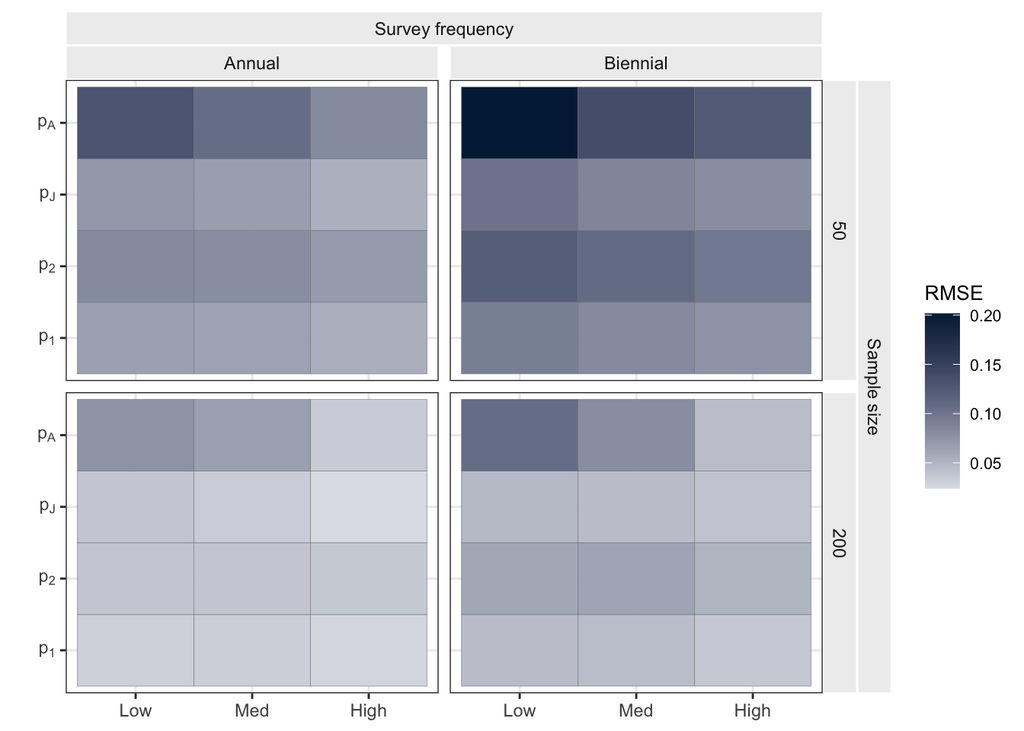